# Lecture 11

November 22, 2017

## Bioconductor

## Bioconductor

Bioconductor provides tools for the analysis and comprehension of high-throughput genomic data, using R.

- 1476 packages
- Covers the bioinformatic pipeline
- Software
- Annotation
- Experiments

## Explore Bioconductor [website](http://www.bioconductor.org)

## Installing Bioconductor packages

This is different from the usual `install.packages`

```r
source('http://bioconductor.org/biocLite.R')
biocLite(c('Biobase','limma','hgu95av2.db','Biostrings'))
```

## DNA sequences

```r
library(Biostrings)
dna <- DNAStringSet(c("AACAT", "GGCGCCT"))
reverseComplement(dna)
```

```
#    A DNAStringSet instance of length 2
#      width seq
#  [1]     5 ATGTT
#  [2]     7 AGGCGCC
```

## DNA sequences

```r
library(Biostrings)
data("phiX174Phage")
phiX174Phage
```

```
#    A DNAStringSet instance of length 6
#      width seq                                          names
#  [1]  5386 GAGTTTTATCGCTTCCATGAC...ATTGGCGTATCCAACCTGCA Genbank
#  [2]  5386 GAGTTTTATCGCTTCCATGAC...ATTGGCGTATCCAACCTGCA RF70s
#  [3]  5386 GAGTTTTATCGCTTCCATGAC...ATTGGCGTATCCAACCTGCA SS78
#  [4]  5386 GAGTTTTATCGCTTCCATGAC...ATTGGCGTATCCAACCTGCA Bull
#  [5]  5386 GAGTTTTATCGCTTCCATGAC...ATTGGCGTATCCAACCTGCA G97
#  [6]  5386 GAGTTTTATCGCTTCCATGAC...ATTGGCGTATCCAACCTGCA NEB03
```

## DNA sequences

```r
letterFrequency(phiX174Phage, 'GC', as.prob=TRUE)
```

```
#             G|C
#  [1,] 0.4476420
#  [2,] 0.4472707
#  [3,] 0.4472707
#  [4,] 0.4470850
#  [5,] 0.4472707
#  [6,] 0.4470850
```

## Data in Bioconductor

The basic structure in a Bioconductor pipeline is the `ExpressionSet`

```r
library(Biobase)
data("sample.ExpressionSet")
str(sample.ExpressionSet)
```

```
#  Formal class 'ExpressionSet' [package "Biobase"] with 7 slots
#    ..@ experimentData   :Formal class 'MIAME' [package "Biobase"] with 13 slots
#    .. .. ..@ name             : chr "Pierre Fermat"
#    .. .. ..@ lab              : chr "Francis Galton Lab"
#    .. .. ..@ contact          : chr "pfermat@lab.not.exist"
#    .. .. ..@ title            : chr "Smoking-Cancer Experiment"
#    .. .. ..@ abstract         : chr "An example object of expression set (ExpressionSet) class"
#    .. .. ..@ url              : chr "www.lab.not.exist"
#    .. .. ..@ pubMedIds        : chr ""
#    .. .. ..@ samples          : list()
#    .. .. ..@ hybridizations   : list()
#    .. .. ..@ normControls     : list()
#    .. .. ..@ preprocessing    : list()
#    .. .. ..@ other            :List of 1
#    .. .. .. ..$ notes: chr "An example object of expression set (exprSet) class"
#    .. .. ..@ .__classVersion__:Formal class 'Versions' [package "Biobase"] with 1 slot
#    .. .. .. .. ..@ .Data:List of 2
#    .. .. .. .. .. ..$ : int [1:3] 1 0 0
#    .. .. .. .. .. ..$ : int [1:3] 1 1 0
#    ..@ assayData        :<environment: 0x1260594d8>
#    ..@ phenoData        :Formal class 'AnnotatedDataFrame' [package "Biobase"] with 4 slots
#    .. .. ..@ varMetadata      :'data.frame':  3 obs. of  1 variable:
#    .. .. .. ..$ labelDescription: chr [1:3] "Female/Male" "Case/Control" "Testing Score"
#    .. .. ..@ data             :'data.frame':  26 obs. of  3 variables:
#    .. .. .. ..$ sex  : Factor w/ 2 levels "Female","Male": 1 2 2 2 1 2 2 2 1 2 ...
#    .. .. .. ..$ type : Factor w/ 2 levels "Case","Control": 2 1 2 1 1 2 1 1 1 2 ...
#    .. .. .. ..$ score: num [1:26] 0.75 0.4 0.73 0.42 0.93 0.22 0.96 0.79 0.37 0.63 ...
#    .. .. ..@ dimLabels        : chr [1:2] "sampleNames" "sampleColumns"
#    .. .. ..@ .__classVersion__:Formal class 'Versions' [package "Biobase"] with 1 slot
#    .. .. .. .. ..@ .Data:List of 1
#    .. .. .. .. .. ..$ : int [1:3] 1 1 0
#    ..@ featureData      :Formal class 'AnnotatedDataFrame' [package "Biobase"] with 4 slots
#    .. .. ..@ varMetadata      :'data.frame':  0 obs. of  1 variable:
#    .. .. .. ..$ labelDescription: chr(0)
#    .. .. ..@ data             :'data.frame':  500 obs. of  0 variables
#    .. .. ..@ dimLabels        : chr [1:2] "featureNames" "featureColumns"
#    .. .. ..@ .__classVersion__:Formal class 'Versions' [package "Biobase"] with 1 slot
#    .. .. .. .. ..@ .Data:List of 1
#    .. .. .. .. .. ..$ : int [1:3] 1 1 0
#    ..@ annotation       : chr "hgu95av2"
#    ..@ protocolData     :Formal class 'AnnotatedDataFrame' [package "Biobase"] with 4 slots
#    .. .. ..@ varMetadata      :'data.frame':  0 obs. of  1 variable:
#    .. .. .. ..$ labelDescription: chr(0)
#    .. .. ..@ data             :'data.frame':  26 obs. of  0 variables
#    .. .. ..@ dimLabels        : chr [1:2] "sampleNames" "sampleColumns"
#    .. .. ..@ .__classVersion__:Formal class 'Versions' [package "Biobase"] with 1 slot
#    .. .. .. .. ..@ .Data:List of 1
#    .. .. .. .. .. ..$ : int [1:3] 1 1 0
#    ..@ .__classVersion__:Formal class 'Versions' [package "Biobase"] with 1 slot
#    .. .. ..@ .Data:List of 4
#    .. .. .. ..$ : int [1:3] 2 13 0
#    .. .. .. ..$ : int [1:3] 2 11 5
#    .. .. .. ..$ : int [1:3] 1 3 0
#    .. .. .. ..$ : int [1:3] 1 0 0
```

## Differences with usual R

Instead of storing data in named lists, ExpressionSet objects store data in **slots**, and we can see what the slots are with `slotNames`:

```r
slotNames(sample.ExpressionSet)
```

```
#  [1] "experimentData"    "assayData"         "phenoData"
#  [4] "featureData"       "annotation"        "protocolData"
#  [7] ".__classVersion__"
```

## Differences with usual R

You can access these slots using `@`, instead of the usual `$`:

```r
sample.ExpressionSet@phenoData
```

```
#  An object of class 'AnnotatedDataFrame'
#    sampleNames: A B ... Z (26 total)
#    varLabels: sex type score
#    varMetadata: labelDescription
```

## Differences with usual R

However, it's much easier to go with the built-in functions

```r
pData(sample.ExpressionSet)
```

```
#       sex    type score
#  A Female Control  0.75
#  B   Male    Case  0.40
#  C   Male Control  0.73
#  D   Male    Case  0.42
#  E Female    Case  0.93
#  F   Male Control  0.22
#  G   Male    Case  0.96
#  H   Male    Case  0.79
#  I Female    Case  0.37
#  J   Male Control  0.63
#  K   Male    Case  0.26
#  L Female Control  0.36
#  M   Male    Case  0.41
#  N   Male    Case  0.80
#  O Female    Case  0.10
#  P Female Control  0.41
#  Q Female    Case  0.16
#  R   Male Control  0.72
#  S   Male    Case  0.17
#  T Female    Case  0.74
#  U   Male Control  0.35
#  V Female Control  0.77
#  W   Male Control  0.27
#  X   Male Control  0.98
#  Y Female    Case  0.94
#  Z Female    Case  0.32
```

## Differences with usual R

```r
head(exprs(sample.ExpressionSet))
```

```
#                         A         B        C        D        E       F
#  AFFX-MurIL2_at  192.7420  85.75330 176.7570 135.5750 64.49390 76.3569
#  AFFX-MurIL10_at  97.1370 126.19600  77.9216  93.3713 24.39860 85.5088
#  AFFX-MurIL4_at   45.8192   8.83135  33.0632  28.7072  5.94492 28.2925
#  AFFX-MurFAS_at   22.5445   3.60093  14.6883  12.3397 36.86630 11.2568
#  AFFX-BioB-5_at   96.7875  30.43800  46.1271  70.9319 56.17440 42.6756
#  AFFX-BioB-M_at   89.0730  25.84610  57.2033  69.9766 49.58220 26.1262
#                         G       H       I         J        K       L
#  AFFX-MurIL2_at  160.5050 65.9631 56.9039 135.60800 63.44320 78.2126
#  AFFX-MurIL10_at  98.9086 81.6932 97.8015  90.48380 70.57330 94.5418
#  AFFX-MurIL4_at   30.9694 14.7923 14.2399  34.48740 20.35210 14.1554
#  AFFX-MurFAS_at   23.0034 16.2134 12.0375   4.54978  8.51782 27.2852
#  AFFX-BioB-5_at   86.5156 30.7927 19.7183  46.35200 39.13260 41.7698
#  AFFX-BioB-M_at   75.0083 42.3352 41.1207  91.53070 39.91360 49.8397
#                        M       N       O       P        Q        R
#  AFFX-MurIL2_at  83.0943 89.3372 91.0615 95.9377 179.8450 152.4670
#  AFFX-MurIL10_at 75.3455 68.5827 87.4050 84.4581  87.6806 108.0320
#  AFFX-MurIL4_at  20.6251 15.9231 20.1579 27.8139  32.7911  33.5292
#  AFFX-MurFAS_at  10.1616 20.2488 15.7849 14.3276  15.9488  14.6753
#  AFFX-BioB-5_at  80.2197 36.4903 36.4021 35.3054  58.6239 114.0620
#  AFFX-BioB-M_at  63.4794 24.7007 47.4641 47.3578  58.1331 104.1220
#                          S       T         U        V       W         X
#  AFFX-MurIL2_at  180.83400 85.4146 157.98900 146.8000 93.8829 103.85500
#  AFFX-MurIL10_at 134.26300 91.4031  -8.68811  85.0212 79.2998  71.65520
#  AFFX-MurIL4_at   19.81720 20.4190  26.87200  31.1488 22.3420  19.01350
#  AFFX-MurFAS_at   -7.91911 12.8875  11.91860  12.8324 11.1390   7.55564
#  AFFX-BioB-5_at   93.44020 22.5168  48.64620  90.2215 42.0053  57.57380
#  AFFX-BioB-M_at  115.83100 58.1224  73.42210  64.6066 40.3068  41.82090
#                        Y         Z
#  AFFX-MurIL2_at  64.4340 175.61500
#  AFFX-MurIL10_at 64.2369  78.70680
#  AFFX-MurIL4_at  12.1686  17.37800
#  AFFX-MurFAS_at  19.9849   8.96849
#  AFFX-BioB-5_at  44.8216  61.70440
#  AFFX-BioB-M_at  46.1087  49.41220
```

## Bioconductor ecosystem

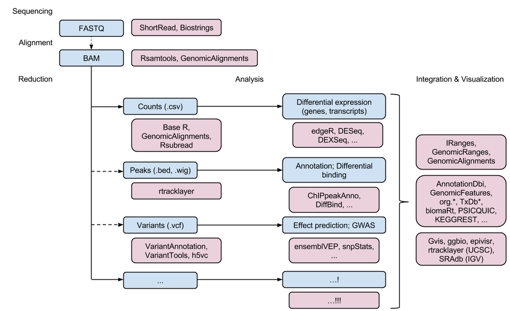

Taken from [Morgan's Bioconductor Tutorial](http://bioconductor.org/help/course-materials/2017/OSU/B1_Bioconductor_intro.html)

## A RNA-Seq pipeline ([link](http://bioconductor.org/help/course-materials/2017/OSU/B3_RNASeq_Workflow.html#lab-gene-level-rna-seq-differential-expression))

## Goals

- Exploratory data analysis
- Differential expression analysis with DESeq2
- Visualization
- We will start after reads have been aligned to a reference genome and reads overlapping known genes have been counted

## The experiment

- In the experiment, four primary human airway smooth muscle cell lines were treated with 1 micromolar dexamethasone for 18 hours.
- For each of the four cell lines, we have a treated and an untreated sample.

## Start with prepared SummarizedExperiment

```r
library(airway)
data(airway)
se <- airway
head(assay(se))
```

```
#                  SRR1039508 SRR1039509 SRR1039512 SRR1039513 SRR1039516
#  ENSG00000000003        679        448        873        408       1138
#  ENSG00000000005          0          0          0          0          0
#  ENSG00000000419        467        515        621        365        587
#  ENSG00000000457        260        211        263        164        245
#  ENSG00000000460         60         55         40         35         78
#  ENSG00000000938          0          0          2          0          1
#                  SRR1039517 SRR1039520 SRR1039521
#  ENSG00000000003       1047        770        572
#  ENSG00000000005          0          0          0
#  ENSG00000000419        799        417        508
#  ENSG00000000457        331        233        229
#  ENSG00000000460         63         76         60
#  ENSG00000000938          0          0          0
```

## Metadata for experiment

```r
colData(se)
```

```
#  DataFrame with 8 rows and 9 columns
#             SampleName     cell      dex    albut        Run avgLength
#               <factor> <factor> <factor> <factor>   <factor> <integer>
#  SRR1039508 GSM1275862   N61311    untrt    untrt SRR1039508       126
#  SRR1039509 GSM1275863   N61311      trt    untrt SRR1039509       126
#  SRR1039512 GSM1275866  N052611    untrt    untrt SRR1039512       126
#  SRR1039513 GSM1275867  N052611      trt    untrt SRR1039513        87
#  SRR1039516 GSM1275870  N080611    untrt    untrt SRR1039516       120
#  SRR1039517 GSM1275871  N080611      trt    untrt SRR1039517       126
#  SRR1039520 GSM1275874  N061011    untrt    untrt SRR1039520       101
#  SRR1039521 GSM1275875  N061011      trt    untrt SRR1039521        98
#             Experiment    Sample    BioSample
#               <factor>  <factor>     <factor>
#  SRR1039508  SRX384345 SRS508568 SAMN02422669
#  SRR1039509  SRX384346 SRS508567 SAMN02422675
#  SRR1039512  SRX384349 SRS508571 SAMN02422678
#  SRR1039513  SRX384350 SRS508572 SAMN02422670
#  SRR1039516  SRX384353 SRS508575 SAMN02422682
#  SRR1039517  SRX384354 SRS508576 SAMN02422673
#  SRR1039520  SRX384357 SRS508579 SAMN02422683
#  SRR1039521  SRX384358 SRS508580 SAMN02422677
```

## Genomic ranges over which counting occurred

```r
rowRanges(se)
```

```
#  GRangesList object of length 64102:
#  $ENSG00000000003
#  GRanges object with 17 ranges and 2 metadata columns:
#         seqnames               ranges strand |   exon_id       exon_name
#            <Rle>            <IRanges>  <Rle> | <integer>     <character>
#     [1]        X [99883667, 99884983]      - |    667145 ENSE00001459322
#     [2]        X [99885756, 99885863]      - |    667146 ENSE00000868868
#     [3]        X [99887482, 99887565]      - |    667147 ENSE00000401072
#     [4]        X [99887538, 99887565]      - |    667148 ENSE00001849132
#     [5]        X [99888402, 99888536]      - |    667149 ENSE00003554016
#     ...      ...                  ...    ... .       ...             ...
#    [13]        X [99890555, 99890743]      - |    667156 ENSE00003512331
#    [14]        X [99891188, 99891686]      - |    667158 ENSE00001886883
#    [15]        X [99891605, 99891803]      - |    667159 ENSE00001855382
#    [16]        X [99891790, 99892101]      - |    667160 ENSE00001863395
#    [17]        X [99894942, 99894988]      - |    667161 ENSE00001828996
#
#  ...
#  <64101 more elements>
#  -------
#  seqinfo: 722 sequences (1 circular) from an unspecified genome
```

## Create a DESeqDataSet

```r
library("DESeq2")
dds <- DESeqDataSet(se, design = ~ cell + dex)
dds
```

```
#  class: DESeqDataSet
#  dim: 64102 8
#  metadata(2): '' version
#  assays(1): counts
#  rownames(64102): ENSG00000000003 ENSG00000000005 ... LRG_98 LRG_99
#  rowData names(0):
#  colnames(8): SRR1039508 SRR1039509 ... SRR1039520 SRR1039521
#  colData names(9): SampleName cell ... Sample BioSample
```

## Fix factor label

```r
dds$dex <- relevel(dds$dex, "untrt")
```

## Run differential expression pipeline

```r
dds <- DESeq(dds)
```

## Extracting results

```r
(res <- results(dds))
```

```
#  log2 fold change (MLE): dex trt vs untrt
#  Wald test p-value: dex trt vs untrt
#  DataFrame with 64102 rows and 6 columns
#                   baseMean log2FoldChange     lfcSE       stat       pvalue
#                  <numeric>      <numeric> <numeric>  <numeric>    <numeric>
#  ENSG00000000003 708.60217    -0.38125388 0.1006560 -3.7876928 0.0001520527
#  ENSG00000000005   0.00000             NA        NA         NA           NA
#  ENSG00000000419 520.29790     0.20681271 0.1122218  1.8428925 0.0653447023
#  ENSG00000000457 237.16304     0.03792050 0.1434532  0.2643405 0.7915175170
#  ENSG00000000460  57.93263    -0.08816322 0.2871677 -0.3070095 0.7588361136
#  ...                   ...            ...       ...        ...          ...
#  LRG_94                  0             NA        NA         NA           NA
#  LRG_96                  0             NA        NA         NA           NA
#  LRG_97                  0             NA        NA         NA           NA
#  LRG_98                  0             NA        NA         NA           NA
#  LRG_99                  0             NA        NA         NA           NA
#                         padj
#                    <numeric>
#  ENSG00000000003 0.001283937
#  ENSG00000000005          NA
#  ENSG00000000419 0.196568379
#  ENSG00000000457 0.911483176
#  ENSG00000000460 0.895073113
#  ...                     ...
#  LRG_94                   NA
#  LRG_96                   NA
#  LRG_97                   NA
#  LRG_98                   NA
#  LRG_99                   NA
```

## Summarizing results

```r
summary(res)
```

```
#
#  out of 33469 with nonzero total read count
#  adjusted p-value < 0.1
#  LFC > 0 (up)     : 2604, 7.8%
#  LFC < 0 (down)   : 2212, 6.6%
#  outliers [1]     : 0, 0%
#  low counts [2]   : 15441, 46%
#  (mean count < 5)
#  [1] see 'cooksCutoff' argument of ?results
#  [2] see 'independentFiltering' argument of ?results
```

## Summarizing results

```r
library(tidyverse)
as.data.frame(res) %>%
  filter(padj < 0.1) %>%
  arrange(desc(abs(log2FoldChange))) %>% head()
```

```
#      baseMean log2FoldChange     lfcSE      stat       pvalue         padj
#  1  67.243048       9.505972 1.0545111  9.014578 1.976299e-19 1.254532e-17
#  2 385.071029       7.352628 0.5363902 13.707610 9.141988e-43 2.257695e-40
#  3  56.318194       6.327393 0.6778153  9.334981 1.010098e-20 7.226210e-19
#  4   5.654654       5.885113 1.3241367  4.444491 8.810031e-06 1.002065e-04
#  5   6.624741      -5.325912 1.2578863 -4.234017 2.295537e-05 2.382495e-04
#  6 286.384119       5.207160 0.4930828 10.560419 4.546302e-26 5.059304e-24
```

## A visualization

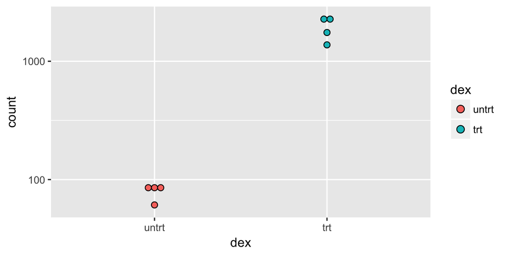

```r
topGene <- rownames(res)[which.min(res$padj)]
data <- plotCounts(dds, gene=topGene, intgroup=c("dex"), returnData=TRUE)
ggplot(data, aes(x = dex, y = count, fill=dex))+
  geom_dotplot(binaxis='y', stackdir='center')+
  scale_y_log10()
```

## Another visualization

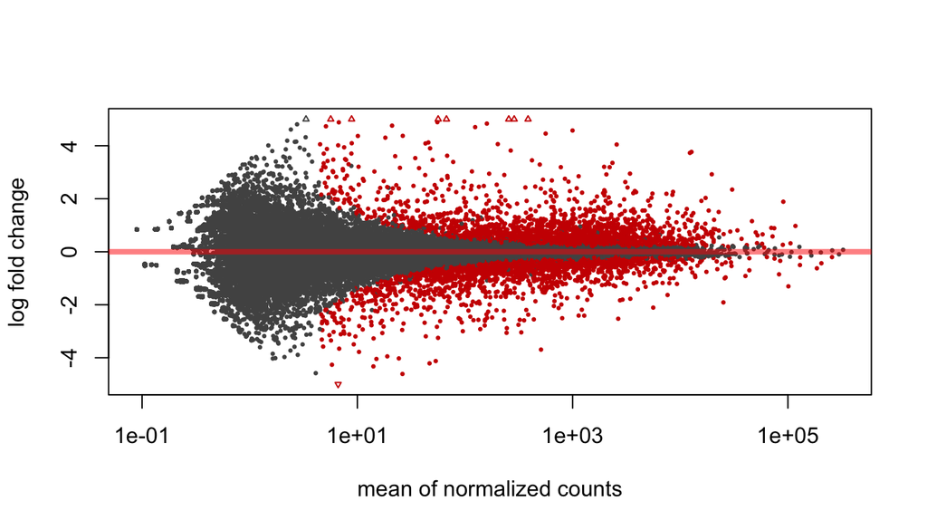

```r
plotMA(res, ylim=c(-5,5))
```

## Making a heatmap

## Heatmaps

There are several ways of doing heatmaps in R:

- http://sebastianraschka.com/Articles/heatmaps_in_r.html
- https://plot.ly/r/heatmaps/
- http://moderndata.plot.ly/interactive-heat-maps-for-r/
- http://www.siliconcreek.net/r/simple-heatmap-in-r-with-ggplot2
- https://rud.is/b/2016/02/14/making-faceted-heatmaps-with-ggplot2/

## Some example data

```r
library(Biobase)
data(sample.ExpressionSet)
exdat <-  sample.ExpressionSet
library(limma)
design1 <- model.matrix(~type, data=pData(exdat))
lm1 <- lmFit(exprs(exdat), design1)
lm1 <- eBayes(lm1) # compute linear model for each probeset
geneID <- rownames(topTable(lm1, coef=2, num=100, adjust='none',p.value=0.05))
exdat2 <- exdat[geneID,] # Keep features with p-values < 0.05
exdat2
```

```
#  ExpressionSet (storageMode: lockedEnvironment)
#  assayData: 46 features, 26 samples
#    element names: exprs, se.exprs
#  protocolData: none
#  phenoData
#    sampleNames: A B ... Z (26 total)
#    varLabels: sex type score
#    varMetadata: labelDescription
#  featureData: none
#  experimentData: use 'experimentData(object)'
#  Annotation: hgu95av2
```

## Heatmaps using `Heatplus`

```r
source('http://bioconductor.org/biocLite.R')
biocLite('Heatplus')
```

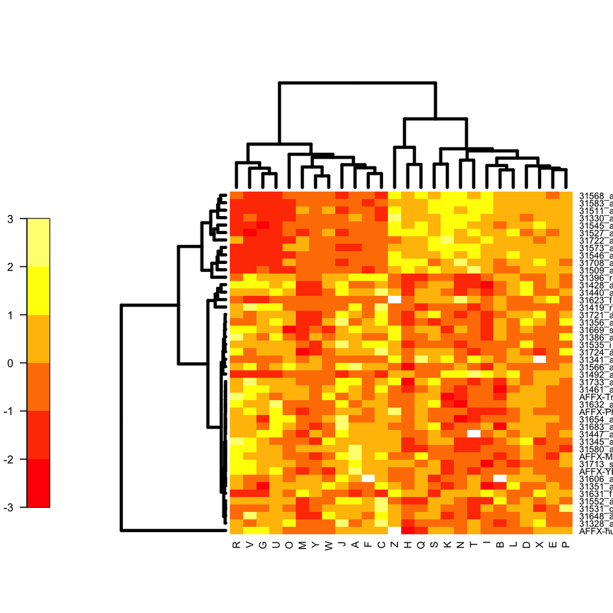

```r
library(Heatplus)
reg1 <- regHeatmap(exprs(exdat2), legend=2, col=heat.colors,
                   breaks=-3:3)
plot(reg1)
```

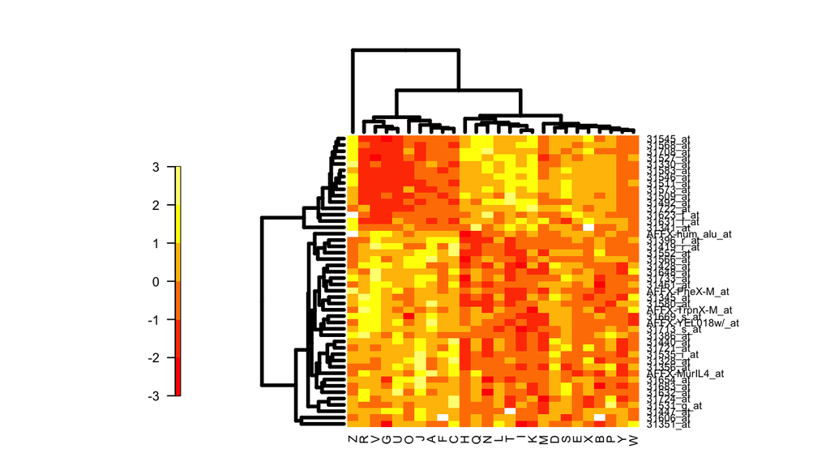

```r
corrdist <- function(x) as.dist(1-cor(t(x)))
hclust.avl <-  function(x) hclust(x, method='average')
reg2 <- regHeatmap(exprs(exdat2), legend=2, col=heat.colors,
                   breaks=-3:3,
                   dendrogram = list(clustfun=hclust.avl, distfun=corrdist))
plot(reg2)
```

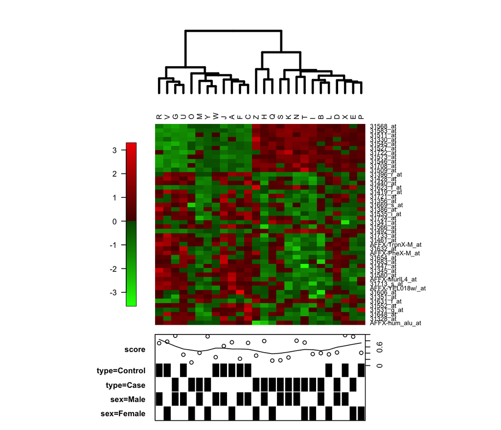

```r
ann1 <- annHeatmap(exprs(exdat2), ann=pData(exdat2))
plot(ann1)
```

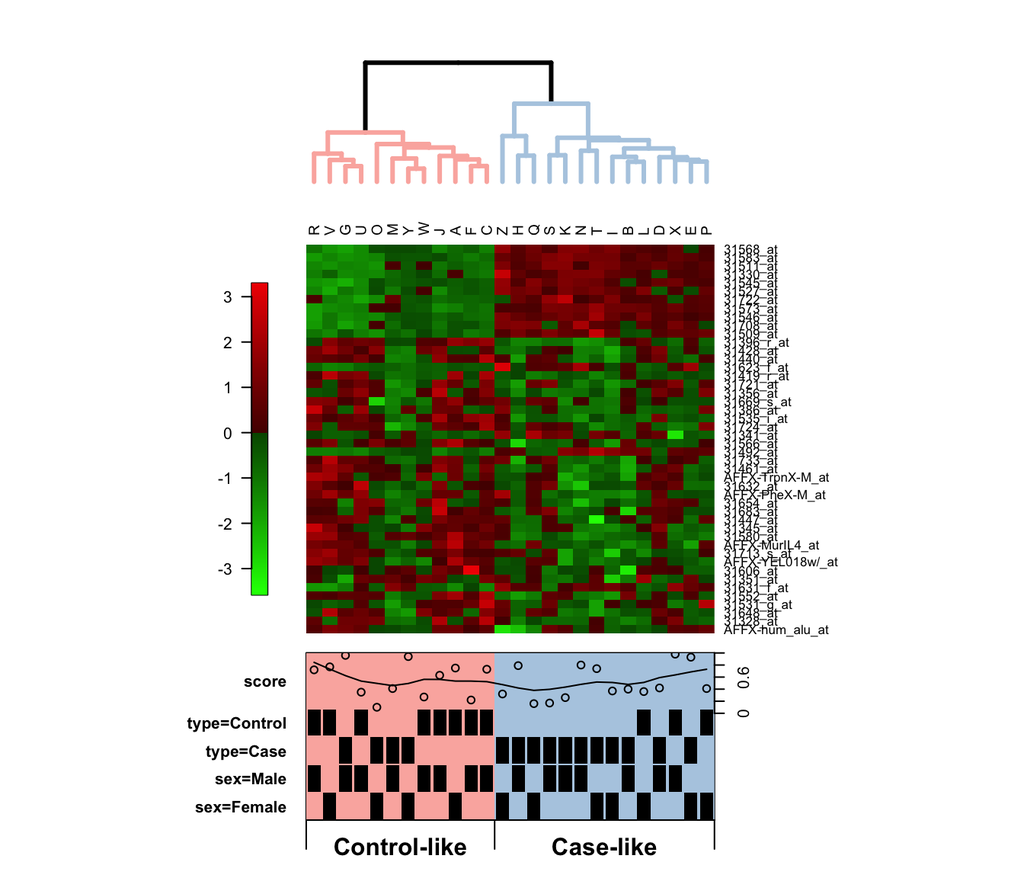

```r
ann2 <- annHeatmap(exprs(exdat2), ann=pData(exdat2),
                   cluster = list(cuth=7500,
                                  label=c('Control-like','Case-like')))
plot(ann2)
```

Put your mouse over each point :)

```r
library(d3heatmap)
d3heatmap(exprs(exdat2), distfun = corrdist,
          hclustfun = hclust.avl, scale='row')
```

[interactive chart not shown]

Put your mouse over each point :)